# 06 CASP-19 Outcome

Yiwen Xiang

# 1 06 CASP-19 Outcome

This file constructs the CASP-19 total score and the binary low-QoL outcome. The cut-off was based on the distribution of CASP-19 total scores in the analytical sample: the lower quartile corresponded to a score of 35. Therefore, respondents with a CASP-19 total score <= 35 were classified as low QoL, while those with scores > 35 were classified as non-low QoL.

## 1.1 Load inputs

## 1.2 Check imported data and metadata

```r
dataset_summary
```

```
##                         dataset n_rows n_cols
## w11_main               w11_main   7842   6433
## w11_ifs                 w11_ifs   7842    404
## w11_financial     w11_financial   7842    667
## w11_nurse             w11_nurse   5097    261
## w11_pensiongrid w11_pensiongrid  11351    202
## w11_lifehistory w11_lifehistory   3176   2892
## w11_eol                 w11_eol    347   2959
```

```r
head(var_w11_all_labeled)
```

```
##      table    variable                              label    type n_missing
## 1 w11_main     idauniq              Cross-wave identifier numeric         0
## 2 w11_main    idahhw11       Wave 11 household identifier numeric         0
## 3 w11_main        mode                     Interview Mode numeric         0
## 4 w11_main       perid             Person Number (PersNo) numeric         0
## 5 w11_main corepartner Whether a Cohort Member or Partner numeric         0
## 6 w11_main      cohort                        ELSA Cohort numeric         0
```

```r
var_label_summary
```

```
## # A tibble: 7 × 5
##   table           n_variables n_with_label n_without_label pct_with_label
##   <chr>                 <int>        <int>           <int>          <dbl>
## 1 w11_eol                2959         2959               0            100
## 2 w11_financial           667          667               0            100
## 3 w11_ifs                 404          404               0            100
## 4 w11_lifehistory        2892         2892               0            100
## 5 w11_main               6433         6433               0            100
## 6 w11_nurse               261          261               0            100
## 7 w11_pensiongrid         202          202               0            100
```

## 1.3 Search CASP-19 / QoL outcome variables

### 1.3.1 Search CASP-19 item variables

```r
casp_general_search <- search_vars(
  keywords = c(
    "CASP",
    "CASP-19",
    "CASP19",
    "quality of life",
    "QoL",
    "control autonomy self-realisation pleasure",
    "control autonomy self-realization pleasure"
  ),
  var_dict = var_w11_all_labeled
) %>%
  filter(table %in% names(w11_datasets))

casp_general_search
```

```
##       table variable
## 1  w11_main   scqola
## 2  w11_main   scqolb
## 3  w11_main   scqolc
## 4  w11_main   scqold
## 5  w11_main   scqole
## 6  w11_main   scqolf
## 7  w11_main   scqolg
## 8  w11_main   scqolh
## 9  w11_main   scqoli
## 10 w11_main   scqolj
## 11 w11_main   scqolk
## 12 w11_main   scqoll
## 13 w11_main   scqolm
## 14 w11_main   scqoln
```

[output cut: 45 more lines]

### 1.3.2 Search existing CASP-19 total score variable

```r
casp_score_search <- search_vars(
  keywords = c(
    "CASP score",
    "CASP total",
    "CASP total score",
    "CASP-19 score",
    "CASP19 score",
    "CASP-19 total",
    "CASP19 total",
    "quality of life score",
    "QoL score",
    "QoL total",
    "total quality of life",
    "summary CASP",
    "summed CASP",
    "CASP scale",
    "CASP index",
    "life satisfaction score",
    "wellbeing score",
    "well-being score"
  ),
  var_dict = var_w11_all_labeled
) %>%
  filter(table %in% names(w11_datasets))

casp_score_search
```

```
## [1] table     variable  label     type      n_missing
## <0 rows> (or 0-length row.names)
```

No directly usable CASP-19 total score variable was confirmed in the searched metadata. Therefore, the total score is calculated from the 19 CASP items.

### 1.3.3 Load the analytical sample

```r
data11_analysis_base <- readRDS(
  file.path(processed_path, "05_wave11_analysis_sample.rds")
)

data_casp <- data11_analysis_base

nrow(data_casp)
```

```
## [1] 6422
```

## 1.4 Confirm CASP-19 item variables

```r
# CASP-19 items are expected to be scqola to scqols.
casp_items <- paste0("scqol", letters[1:19])

casp_items
```

```
##  [1] "scqola" "scqolb" "scqolc" "scqold" "scqole" "scqolf" "scqolg" "scqolh"
##  [9] "scqoli" "scqolj" "scqolk" "scqoll" "scqolm" "scqoln" "scqolo" "scqolp"
## [17] "scqolq" "scqolr" "scqols"
```

```r
casp_items <- paste0("scqol", letters[1:19])

negative_items <- c(
  "scqola",
  "scqolb",
  "scqold",
  "scqolf",
  "scqolh",
  "scqoli"
)

positive_items <- setdiff(casp_items, negative_items)

casp_raw_items <- paste0(casp_items, "_raw")
casp_score_items <- paste0(casp_items, "_score")

casp_items
```

```
##  [1] "scqola" "scqolb" "scqolc" "scqold" "scqole" "scqolf" "scqolg" "scqolh"
##  [9] "scqoli" "scqolj" "scqolk" "scqoll" "scqolm" "scqoln" "scqolo" "scqolp"
## [17] "scqolq" "scqolr" "scqols"
```

```r
negative_items
```

```
## [1] "scqola" "scqolb" "scqold" "scqolf" "scqolh" "scqoli"
```

```r
positive_items
```

```
##  [1] "scqolc" "scqole" "scqolg" "scqolj" "scqolk" "scqoll" "scqolm" "scqoln"
##  [9] "scqolo" "scqolp" "scqolq" "scqolr" "scqols"
```

```r
missing_casp_items <- setdiff(casp_items, names(data_casp))

if (length(missing_casp_items) > 0) {
  stop(
    "These CASP-19 variables are missing from data_casp: ",
    paste(missing_casp_items, collapse = ", ")
  )
}
```

## 1.5 Check raw CASP-19 missingness and invalid codes

```r
casp_missing_raw <- purrr::map_dfr(casp_items, function(v) {
  x <- suppressWarnings(as.numeric(data_casp[[v]]))

  tibble::tibble(
    variable = v,
    n_total = length(x),
    n_raw_na = sum(is.na(x)),
    n_negative_code = sum(!is.na(x) & x < 0),
    n_outside_1_4_positive = sum(!is.na(x) & x >= 0 & !x %in% 1:4),
    pct_negative_code = round(mean(!is.na(x) & x < 0) * 100, 2)
  )
})

casp_missing_raw
```

```
## # A tibble: 19 × 6
##    variable n_total n_raw_na n_negative_code n_outside_1_4_positive
##    <chr>      <int>    <int>           <int>                  <int>
##  1 scqola      6422        0             741                      0
##  2 scqolb      6422        0             779                      0
##  3 scqolc      6422        0             789                      0
##  4 scqold      6422        0             772                      0
##  5 scqole      6422        0             764                      0
##  6 scqolf      6422        0             775                      0
##  7 scqolg      6422        0             784                      0
##  8 scqolh      6422        0             763                      0
##  9 scqoli      6422        0             771                      0
## 10 scqolj      6422        0             755                      0
## 11 scqolk      6422        0             763                      0
## 12 scqoll      6422        0             750                      0
## 13 scqolm      6422        0             754                      0
## 14 scqoln      6422        0             773                      0
## 15 scqolo      6422        0             761                      0
## 16 scqolp      6422        0             783                      0
## 17 scqolq      6422        0             784                      0
## 18 scqolr      6422        0             776                      0
## 19 scqols      6422        0             757                      0
## # ℹ 1 more variable: pct_negative_code <dbl>
```

## 1.6 Create cleaned raw CASP item variables

```r
clean_casp_item <- function(x) {
  x <- suppressWarnings(as.numeric(x))

  # ELSA negative response codes are treated as missing
  x[x < 0] <- NA_real_

  # Valid raw CASP item responses should only be 1, 2, 3, or 4
  x[!is.na(x) & !x %in% 1:4] <- NA_real_

  x
}

data_casp <- data_casp %>%
  mutate(
    across(
      all_of(casp_items),
      clean_casp_item,
      .names = "{.col}_raw"
    )
  )
```

```r
casp_clean_missing_by_item <- purrr::map_dfr(casp_raw_items, function(v) {
  x <- data_casp[[v]]

  tibble::tibble(
    variable = v,
    n_missing = sum(is.na(x)),
    pct_missing = round(mean(is.na(x)) * 100, 2),
    n_valid = sum(!is.na(x)),
    min_value = min(x, na.rm = TRUE),
    max_value = max(x, na.rm = TRUE)
  )
})

casp_clean_missing_by_item
```

```
## # A tibble: 19 × 6
##    variable   n_missing pct_missing n_valid min_value max_value
##    <chr>          <int>       <dbl>   <int>     <dbl>     <dbl>
##  1 scqola_raw       741        11.5    5681         1         4
##  2 scqolb_raw       779        12.1    5643         1         4
##  3 scqolc_raw       789        12.3    5633         1         4
##  4 scqold_raw       772        12.0    5650         1         4
##  5 scqole_raw       764        11.9    5658         1         4
##  6 scqolf_raw       775        12.1    5647         1         4
##  7 scqolg_raw       784        12.2    5638         1         4
##  8 scqolh_raw       763        11.9    5659         1         4
##  9 scqoli_raw       771        12.0    5651         1         4
## 10 scqolj_raw       755        11.8    5667         1         4
## 11 scqolk_raw       763        11.9    5659         1         4
## 12 scqoll_raw       750        11.7    5672         1         4
## 13 scqolm_raw       754        11.7    5668         1         4
## 14 scqoln_raw       773        12.0    5649         1         4
## 15 scqolo_raw       761        11.8    5661         1         4
## 16 scqolp_raw       783        12.2    5639         1         4
## 17 scqolq_raw       784        12.2    5638         1         4
## 18 scqolr_raw       776        12.1    5646         1         4
## 19 scqols_raw       757        11.8    5665         1         4
```

## 1.7 Count valid and missing CASP-19 items per participant

```r
data_casp <- data_casp %>%
  mutate(
    casp19_n_valid_items = rowSums(!is.na(select(., all_of(casp_raw_items)))),
    casp19_n_missing_items = length(casp_raw_items) - casp19_n_valid_items
  )

table(data_casp$casp19_n_missing_items, useNA = "ifany")
```

```
##
##    0    1    2    3    4    5    6    7    8    9   10   11   12   13   14   15
## 5314  270   57   10   11    4    3    2    2    1    3    6    1    2    5    4
##   17   18   19
##    7    4  716
```

```r
data_casp %>%
  summarise(
    n_total = n(),
    n_complete_19_items = sum(casp19_n_valid_items == 19),
    n_incomplete_items = sum(casp19_n_valid_items < 19),
    pct_complete_19_items = round(mean(casp19_n_valid_items == 19) * 100, 2)
  )
```

```
## # A tibble: 1 × 4
##   n_total n_complete_19_items n_incomplete_items pct_complete_19_items
##     <int>               <int>              <int>                 <dbl>
## 1    6422                5314               1108                  82.8
```

This check shows that 5,314 of the 6,422 core Wave 11 respondents had complete CASP-19 item data. Since this study used a complete-case approach for the outcome variable, the 1,108 respondents with missing or invalid CASP-19 item responses were excluded from the outcome-valid analytical sample.

## 1.8 Recode CASP-19 items into 0-3 score variables

Before calculating the CASP-19 total score, all items were recoded onto a 0-3 scale so that higher values consistently represented better QoL. Negatively worded items were scored as `raw response - 1`, while positively worded items were reverse-coded as `4 - raw response`. The 19 recoded item scores were then summed to create the CASP-19 total score, with a possible range from 0 to 57.

```r
for (v in negative_items) {
  raw_var <- paste0(v, "_raw")
  score_var <- paste0(v, "_score")

  data_casp[[score_var]] <- data_casp[[raw_var]] - 1
}

for (v in positive_items) {
  raw_var <- paste0(v, "_raw")
  score_var <- paste0(v, "_score")

  data_casp[[score_var]] <- 4 - data_casp[[raw_var]]
}
```

```r
casp_scored_range_check <- purrr::map_dfr(casp_score_items, function(v) {
  x <- data_casp[[v]]

  tibble::tibble(
    variable = v,
    min_value = min(x, na.rm = TRUE),
    max_value = max(x, na.rm = TRUE),
    n_outside_0_3 = sum(!is.na(x) & !x %in% 0:3)
  )
})

casp_scored_range_check
```

```
## # A tibble: 19 × 4
##    variable     min_value max_value n_outside_0_3
##    <chr>            <dbl>     <dbl>         <int>
##  1 scqola_score         0         3             0
##  2 scqolb_score         0         3             0
##  3 scqolc_score         0         3             0
##  4 scqold_score         0         3             0
##  5 scqole_score         0         3             0
##  6 scqolf_score         0         3             0
##  7 scqolg_score         0         3             0
##  8 scqolh_score         0         3             0
##  9 scqoli_score         0         3             0
## 10 scqolj_score         0         3             0
## 11 scqolk_score         0         3             0
## 12 scqoll_score         0         3             0
## 13 scqolm_score         0         3             0
## 14 scqoln_score         0         3             0
## 15 scqolo_score         0         3             0
## 16 scqolp_score         0         3             0
## 17 scqolq_score         0         3             0
## 18 scqolr_score         0         3             0
## 19 scqols_score         0         3             0
```

```r
if (any(casp_scored_range_check$n_outside_0_3 > 0)) {
  stop("Some scored CASP items are outside the expected range 0-3.")
}
```

## 1.9 Calculate CASP-19 total score

```r
data_casp <- data_casp %>%
  mutate(
    casp19_total = ifelse(
      casp19_n_missing_items == 0,
      rowSums(select(., all_of(casp_score_items)), na.rm = FALSE),
      NA_real_
    )
  )
```

```r
casp19_range_check <- data_casp %>%
  summarise(
    n_valid = sum(!is.na(casp19_total)),
    n_missing = sum(is.na(casp19_total)),
    min_score = min(casp19_total, na.rm = TRUE),
    max_score = max(casp19_total, na.rm = TRUE),
    n_below_0 = sum(casp19_total < 0, na.rm = TRUE),
    n_above_57 = sum(casp19_total > 57, na.rm = TRUE)
  )

casp19_range_check
```

```
## # A tibble: 1 × 6
##   n_valid n_missing min_score max_score n_below_0 n_above_57
##     <int>     <int>     <dbl>     <dbl>     <int>      <int>
## 1    5314      1108         2        57         0          0
```

## 1.10 Descriptive statistics for QoL score

```r
casp19_summary <- data_casp %>%
  summarise(
    n_total = n(),
    n_valid = sum(!is.na(casp19_total)),
    n_missing = sum(is.na(casp19_total)),
    missing_pct = round(mean(is.na(casp19_total)) * 100, 2),
    mean = round(mean(casp19_total, na.rm = TRUE), 2),
    median = round(median(casp19_total, na.rm = TRUE), 2),
    sd = round(sd(casp19_total, na.rm = TRUE), 2),
    min = min(casp19_total, na.rm = TRUE),
    q1 = round(quantile(casp19_total, 0.25, na.rm = TRUE), 2),
    q3 = round(quantile(casp19_total, 0.75, na.rm = TRUE), 2),
    max = max(casp19_total, na.rm = TRUE)
  )

casp19_summary
```

```
## # A tibble: 1 × 11
##   n_total n_valid n_missing missing_pct  mean median    sd   min    q1    q3
##     <int>   <int>     <int>       <dbl> <dbl>  <dbl> <dbl> <dbl> <dbl> <dbl>
## 1    6422    5314      1108        17.2  41.1     43  9.43     2    35    48
## # ℹ 1 more variable: max <dbl>
```

## 1.11 Define low QoL using the fixed CASP-19 cutoff

```r
qol_q1_cutoff <- 35

qol_q1_cutoff
```

```
## [1] 35
```

```r
data_casp <- data_casp %>%
  mutate(
    qol_group = case_when(
      is.na(casp19_total) ~ NA_character_,
      casp19_total <= qol_q1_cutoff ~ "Low QoL",
      casp19_total > qol_q1_cutoff ~ "Non-low QoL"
    ),

    low_qol = case_when(
      is.na(casp19_total) ~ NA_real_,
      casp19_total <= qol_q1_cutoff ~ 1,
      casp19_total > qol_q1_cutoff ~ 0
    ),

    qol_group = factor(
      qol_group,
      levels = c("Non-low QoL", "Low QoL")
    )
  )
```

```r
qol_group_balance <- data_casp %>%
  filter(!is.na(qol_group)) %>%
  count(qol_group, name = "n") %>%
  mutate(
    pct = round(n / sum(n) * 100, 2)
  )

qol_group_balance
```

```
## # A tibble: 2 × 3
##   qol_group       n   pct
##   <fct>       <int> <dbl>
## 1 Non-low QoL  3970  74.7
## 2 Low QoL      1344  25.3
```

## 1.12 Plot CASP-19 distribution

The optimized plot first restricts the figure to respondents with valid CASP-19 total scores, which matches the complete-case outcome analysis and avoids missing-value warnings. The display range is controlled with `coord_cartesian()` rather than scale limits, so boundary values are not removed. The mean and lower-quartile cut-off lines are drawn as fixed-height segments and labelled directly in the plot, making the figure cleaner and easier to interpret.

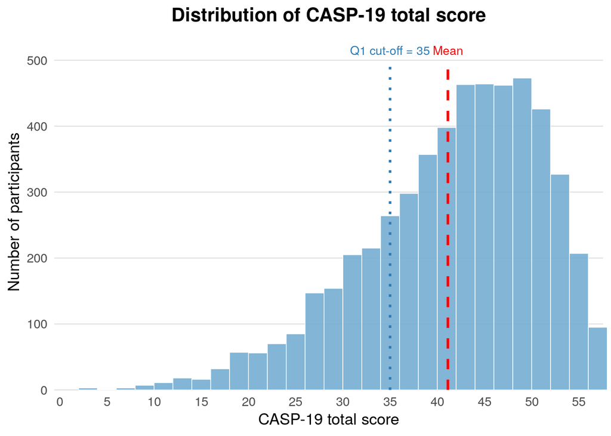

```r
data_casp_plot <- data_casp %>%
  filter(!is.na(casp19_total))

mean_casp19 <- mean(data_casp_plot$casp19_total)

y_line_top <- 490
y_label_top <- 515

casp19_distribution_plot <- ggplot(data_casp_plot, aes(x = casp19_total)) +
  geom_histogram(
    binwidth = 2,
    boundary = 0,
    closed = "left",
    fill = "#74ADD1",
    color = "white",
    linewidth = 0.25,
    alpha = 0.9
  ) +
  annotate(
    "segment",
    x = mean_casp19,
    xend = mean_casp19,
    y = 0,
    yend = y_line_top,
    color = "red",
    linewidth = 1,
    linetype = "dashed"
  ) +
  annotate(
    "segment",
    x = qol_q1_cutoff,
    xend = qol_q1_cutoff,
    y = 0,
    yend = y_line_top,
    color = "#2C7BB6",
    linewidth = 1,
    linetype = "dotted"
  ) +
  annotate(
    "text",
    x = mean_casp19,
    y = y_label_top,
    label = "Mean",
    color = "red",
    size = 3.5,
    hjust = 0.5
  ) +
  annotate(
    "text",
    x = qol_q1_cutoff,
    y = y_label_top,
    label = "Q1 cut-off = 35",
    color = "#2C7BB6",
    size = 3.5,
    hjust = 0.5
  ) +
  scale_x_continuous(
    breaks = seq(0, 55, by = 5),
    expand = expansion(mult = c(0.01, 0.01))
  ) +
  scale_y_continuous(
    breaks = seq(0, 500, by = 100),
    expand = expansion(mult = c(0, 0))
  ) +
  coord_cartesian(
    xlim = c(0, 57),
    ylim = c(0, 540),
    clip = "off"
  ) +
  labs(
    title = "Distribution of CASP-19 total score",
    x = "CASP-19 total score",
    y = "Number of participants"
  ) +
  theme_minimal(base_size = 13) +
  theme(
    plot.title = element_text(hjust = 0.5, face = "bold"),
    panel.grid.major.x = element_blank(),
    panel.grid.minor.x = element_blank(),
    panel.grid.major.y = element_line(color = "grey88", linewidth = 0.4),
    panel.grid.minor.y = element_blank(),
    panel.background = element_rect(fill = "white", color = NA),
    plot.background = element_rect(fill = "white", color = NA)
  )

casp19_distribution_plot
```

```r
ggsave(
  filename = file.path(picture_path, "06_casp19_total_score_distribution.jpg"),
  plot = casp19_distribution_plot,
  width = 8.5,
  height = 5.2,
  units = "in",
  dpi = 300,
  bg = "white"
)
```

### 1.12.1 final output check

```r
list(
  n_total = nrow(data_casp),
  n_valid_casp19 = sum(!is.na(data_casp$casp19_total)),
  n_missing_casp19 = sum(is.na(data_casp$casp19_total)),
  casp19_min = min(data_casp$casp19_total, na.rm = TRUE),
  casp19_max = max(data_casp$casp19_total, na.rm = TRUE),
  q1_cutoff = qol_q1_cutoff,
  low_qol_n = sum(data_casp$low_qol == 1, na.rm = TRUE),
  non_low_qol_n = sum(data_casp$low_qol == 0, na.rm = TRUE)
)
```

```
## $n_total
## [1] 6422
##
## $n_valid_casp19
## [1] 5314
##
## $n_missing_casp19
## [1] 1108
##
## $casp19_min
## [1] 2
##
## $casp19_max
## [1] 57
##
## $q1_cutoff
## [1] 35
##
## $low_qol_n
## [1] 1344
##
## $non_low_qol_n
## [1] 3970
```

## 1.13 Create the outcome-valid analytical sample

```r
# Create outcome-valid analysis sample

data11_analysis_outcome_valid <- data_casp %>%
  filter(
    !is.na(casp19_total),
    casp19_total >= 0,
    casp19_total <= 57
  )

outcome_valid_summary <- tibble::tibble(
  n_base_sample = nrow(data_casp),
  n_outcome_valid = nrow(data11_analysis_outcome_valid),
  n_outcome_excluded = nrow(data_casp) - nrow(data11_analysis_outcome_valid),
  pct_outcome_excluded = round(
    (nrow(data_casp) - nrow(data11_analysis_outcome_valid)) / nrow(data_casp) * 100,
    2
  )
)

outcome_valid_summary
```

```
## # A tibble: 1 × 4
##   n_base_sample n_outcome_valid n_outcome_excluded pct_outcome_excluded
##           <int>           <int>              <int>                <dbl>
## 1          6422            5314               1108                 17.2
```

```r
# Save outcome-valid full analysis sample

saveRDS(
  data11_analysis_outcome_valid,
  file.path(processed_path, "06_wave11_outcome.rds")
)
```